# Analysis of Illumina microarray data

**Authors**: *Momeneh (Sepideh) Foroutan* and *Ramyar Molania*

We are going to analyse Illumina platform “HumanWG-6 v3.0 expression beadchip” with GEO accession number “GSE20247”. For Illumina, we usually have one single “.txt” file containing all the arrays in columns. It is recommended that the data are exported from the machine without any pre-processing. Intensity for control probes are usually written in a separate file, and if available, it can be read at the same time that we read Illumina probe summary file.

```r
pkgPath<- "/Users/Sepideh/Documents/Scripts/FreqUsedScripts/"
source(paste0(pkgPath, "RequiredPackagesMicroarrayAnanlysis.R"))

# source("http://bioconductor.org/biocLite.R")
# biocLite(c("GEOquery", "limma", "dplyr", "ggplot2", "edgeR", "RSubread", "affy", "matrixStats"))
# library(limma)
```

## Download and read the data

```r
## processed data and sample info:
gse <- getGEO("GSE20247", GSEMatrix = TRUE)
save(gse, file="gse.RData")
## raw data:
GEOrawPath<- getGEOSuppFiles("GSE20247")

## untar the raw data:
untar("./GSE20247/GSE20247_RAW.tar")
gunzip("./GSE20247/GSE20247_non-normalized_Sample_Probe_Profile_BSonly.txt.gz")
```

Now we want to read the data. Reading the control probe profiles is optional but recommended. If the control probe profiles are available, then the Illumina data can be favorably background corrected and normalized using the neqc or nec functions.

```r
## Now we read the data; this is an object of class "EListRaw"
data <- read.ilmn("./GSE20247/GSE20247_non-normalized_Sample_Probe_Profile_BSonly.txt",
                  probeid="ProbeID",
                  annotation = c("ID_REF", "TargetID"))
```

```
Reading file ./GSE20247/GSE20247_non-normalized_Sample_Probe_Profile_BSonly.txt ... ...
```

Read the manifest file that has annotation related to probes. This annotation file can be downloaded from the GEO website here.

```r
gunzip("./GPL6884_HumanWG-6_V3_0_R0_11282955_A.bgx.gz")
Manifest <- read.delim("GPL6884_HumanWG-6_V3_0_R0_11282955_A.bgx",skip=8,comment.char="",quote="",stringsAsFactors=FALSE,nrows=48804)
```

## Add gene and sample information

We need to add gene IDs (EntrezIDs) to probe annotations.

```r
## get gene Symbols in the same order as the row.names in the data:
mIndx <- match(rownames(data), Manifest$Array_Address_Id)
Symbol <- Manifest$Symbol[mIndx]
## get gene IDs and and add that to the data:
geneInfo<- alias2SymbolUsingNCBI(Symbol,"Homo_sapiens.gene_info")
data$genes <- data.frame(data$genes, geneInfo)
```

Generate sampleInfo from the pData, and add a column containing groups

```r
gse[[1]]  ## normalised data: expressionSet
```

```
ExpressionSet (storageMode: lockedEnvironment)
assayData: 48803 features, 18 samples
  element names: exprs
protocolData: none
phenoData
  sampleNames: GSM507414 GSM507415 ... GSM507431 (18 total)
  varLabels: title geo_accession ... data_row_count (34 total)
  varMetadata: labelDescription
featureData
  featureNames: ILMN_1343291 ILMN_1343295 ... ILMN_2416019 (48803 total)
  fvarLabels: ID Species ... GB_ACC (28 total)
  fvarMetadata: Column Description labelDescription
experimentData: use 'experimentData(object)'
Annotation: GPL6884
```

```r
## look at the processed data:
head(exprs(gse[[1]]))
```

```
             GSM507414 GSM507415 GSM507416 GSM507417 GSM507418 GSM507419 GSM507420
ILMN_1343291   26739.7   25212.1   25842.2   25382.6   26332.1   29255.7   29255.7
ILMN_1343295    6393.4    7296.3    7125.0    7345.0    7689.0    7242.7    7764.7
ILMN_1651199      -1.1      -0.1      -4.4      -1.0       2.2       0.2       1.3
ILMN_1651209      16.2      11.9      24.0      10.0      11.6       5.4       4.7
ILMN_1651210      -0.8       0.0       3.2      -0.1       0.8       4.2      -0.3
ILMN_1651221       7.6       1.5       6.4      -1.7      -1.0       1.2      -0.6
             GSM507421 GSM507422 GSM507423 GSM507424 GSM507425 GSM507426 GSM507427
ILMN_1343291   26739.7   29255.7   25382.6   26739.7   24847.6   25842.2   25212.1
ILMN_1343295    8151.2    7367.2    6845.2    6569.9    6657.8    7185.1    6096.3
ILMN_1651199       1.4      -0.3      -1.6       0.7       3.7      -0.2       1.1
ILMN_1651209      12.8       8.4       7.4      16.9       6.3      14.4       8.4
ILMN_1651210      -6.6      -3.4      -1.7      -3.5       0.4      -0.4       2.1
ILMN_1651221       0.1       9.3       5.2       0.5       4.4       7.1       1.5
             GSM507428 GSM507429 GSM507430 GSM507431
ILMN_1343291   27978.8   27978.8   29255.7   29255.7
ILMN_1343295    7033.3    7125.0    7097.0    6967.0
ILMN_1651199      -2.5       3.6      -3.4      -0.1
ILMN_1651209       6.8       9.9       4.4      10.7
ILMN_1651210       2.5      -1.3      -3.0      -1.3
ILMN_1651221       3.9       1.7       1.6       8.0
```

```r
## look at the phenotypic data:
dim(pData(gse[[1]]))
```

```
[1] 18 34
```

```r
head(pData(gse[[1]]))
```

|  | title | geo_accession | status | submission_date | last_update_date | type | channel_count | source_name_ch1 | organism_ch1 | characteristics_ch1 | treatment_protocol_ch1 | growth_protocol_ch1 | molecule_ch1 | extract_protocol_ch1 | label_ch1 | label_protocol_ch1 | taxid_ch1 | hyb_protocol | scan_protocol | description | data_processing | platform_id | contact_name | contact_email | contact_phone | contact_department | contact_institute | contact_address | contact_city | … |
| --- | --- | --- | --- | --- | --- | --- | --- | --- | --- | --- | --- | --- | --- | --- | --- | --- | --- | --- | --- | --- | --- | --- | --- | --- | --- | --- | --- | --- | --- | --- |
| GSM507414 | Control_48hrs_rep1 | GSM507414 | Public on Feb 11 2010 | Feb 09 2010 | Feb 12 2010 | RNA | 1 | HK-2 cells | Homo sapiens | cell line: HK-2 | For microarray analyses, cells were cultured in 5mM-DMEM/F12 without supplements (control) or with 5nM C-peptide for either 18h or 48h. Alternatively, cells were treated with 2ng/ml TGF-b1 either alon… | HK-2 cells (passages 18-30) were maintained in DMEM/Hams F12 (DMEM/F12) (17.5mM glucose), supplemented with 10% fetal calf serum (FCS), glutamine (2mM), penicillin (100 IU/ml) and streptomycin (100ng/… | total RNA | RNA was prepared by acid-guanidinium extraction using a Genelute mammalian total RNA miniprep kit (Sigma-Aldrich, Poole, UK) following the manufacturer’s instructions. | biotin | Standard Illumina hybridization protocol performed by Geneservice (Cambridge, UK) | 9606 | Standard Illumina hybridization protocol performed by Geneservice (Cambridge, UK) | Standard Illumina scanning protocol performed by Geneservice (Cambridge, UK) | HK-2 cells cultured 48h without supplements | The array intensity data were analysed using Illumina GenomeStudio Gene Expression Module (v1.1.1) (Illumina Cambridge, UK) for visualisation and normalisation. The quantile normalisation method was u… | GPL6884 | Nigel,John,Brunskill | njb18@le.ac.uk | +44 116 2588043 | Infection Immunity and Inflammation | University of Leicester | University Road | Leicester | … |
| GSM507415 | Control_48hrs_rep2 | GSM507415 | Public on Feb 11 2010 | Feb 09 2010 | Feb 12 2010 | RNA | 1 | HK-2 cells | Homo sapiens | cell line: HK-2 | For microarray analyses, cells were cultured in 5mM-DMEM/F12 without supplements (control) or with 5nM C-peptide for either 18h or 48h. Alternatively, cells were treated with 2ng/ml TGF-b1 either alon… | HK-2 cells (passages 18-30) were maintained in DMEM/Hams F12 (DMEM/F12) (17.5mM glucose), supplemented with 10% fetal calf serum (FCS), glutamine (2mM), penicillin (100 IU/ml) and streptomycin (100ng/… | total RNA | RNA was prepared by acid-guanidinium extraction using a Genelute mammalian total RNA miniprep kit (Sigma-Aldrich, Poole, UK) following the manufacturer’s instructions. | biotin | Standard Illumina hybridization protocol performed by Geneservice (Cambridge, UK) | 9606 | Standard Illumina hybridization protocol performed by Geneservice (Cambridge, UK) | Standard Illumina scanning protocol performed by Geneservice (Cambridge, UK) | HK-2 cells cultured 48h without supplements | The array intensity data were analysed using Illumina GenomeStudio Gene Expression Module (v1.1.1) (Illumina Cambridge, UK) for visualisation and normalisation. The quantile normalisation method was u… | GPL6884 | Nigel,John,Brunskill | njb18@le.ac.uk | +44 116 2588043 | Infection Immunity and Inflammation | University of Leicester | University Road | Leicester | … |
| GSM507416 | Control_48hrs_rep3 | GSM507416 | Public on Feb 11 2010 | Feb 09 2010 | Feb 12 2010 | RNA | 1 | HK-2 cells | Homo sapiens | cell line: HK-2 | For microarray analyses, cells were cultured in 5mM-DMEM/F12 without supplements (control) or with 5nM C-peptide for either 18h or 48h. Alternatively, cells were treated with 2ng/ml TGF-b1 either alon… | HK-2 cells (passages 18-30) were maintained in DMEM/Hams F12 (DMEM/F12) (17.5mM glucose), supplemented with 10% fetal calf serum (FCS), glutamine (2mM), penicillin (100 IU/ml) and streptomycin (100ng/… | total RNA | RNA was prepared by acid-guanidinium extraction using a Genelute mammalian total RNA miniprep kit (Sigma-Aldrich, Poole, UK) following the manufacturer’s instructions. | biotin | Standard Illumina hybridization protocol performed by Geneservice (Cambridge, UK) | 9606 | Standard Illumina hybridization protocol performed by Geneservice (Cambridge, UK) | Standard Illumina scanning protocol performed by Geneservice (Cambridge, UK) | HK-2 cells cultured 48h without supplements | The array intensity data were analysed using Illumina GenomeStudio Gene Expression Module (v1.1.1) (Illumina Cambridge, UK) for visualisation and normalisation. The quantile normalisation method was u… | GPL6884 | Nigel,John,Brunskill | njb18@le.ac.uk | +44 116 2588043 | Infection Immunity and Inflammation | University of Leicester | University Road | Leicester | … |
| GSM507417 | Control_18hrs_rep1 | GSM507417 | Public on Feb 11 2010 | Feb 09 2010 | Feb 12 2010 | RNA | 1 | HK-2 cells | Homo sapiens | cell line: HK-2 | For microarray analyses, cells were cultured in 5mM-DMEM/F12 without supplements (control) or with 5nM C-peptide for either 18h or 48h. Alternatively, cells were treated with 2ng/ml TGF-b1 either alon… | HK-2 cells (passages 18-30) were maintained in DMEM/Hams F12 (DMEM/F12) (17.5mM glucose), supplemented with 10% fetal calf serum (FCS), glutamine (2mM), penicillin (100 IU/ml) and streptomycin (100ng/… | total RNA | RNA was prepared by acid-guanidinium extraction using a Genelute mammalian total RNA miniprep kit (Sigma-Aldrich, Poole, UK) following the manufacturer’s instructions. | biotin | Standard Illumina hybridization protocol performed by Geneservice (Cambridge, UK) | 9606 | Standard Illumina hybridization protocol performed by Geneservice (Cambridge, UK) | Standard Illumina scanning protocol performed by Geneservice (Cambridge, UK) | HK-2 cells cultured 18h without supplements | The array intensity data were analysed using Illumina GenomeStudio Gene Expression Module (v1.1.1) (Illumina Cambridge, UK) for visualisation and normalisation. The quantile normalisation method was u… | GPL6884 | Nigel,John,Brunskill | njb18@le.ac.uk | +44 116 2588043 | Infection Immunity and Inflammation | University of Leicester | University Road | Leicester | … |
| GSM507418 | Control_18hrs_rep2 | GSM507418 | Public on Feb 11 2010 | Feb 09 2010 | Feb 12 2010 | RNA | 1 | HK-2 cells | Homo sapiens | cell line: HK-2 | For microarray analyses, cells were cultured in 5mM-DMEM/F12 without supplements (control) or with 5nM C-peptide for either 18h or 48h. Alternatively, cells were treated with 2ng/ml TGF-b1 either alon… | HK-2 cells (passages 18-30) were maintained in DMEM/Hams F12 (DMEM/F12) (17.5mM glucose), supplemented with 10% fetal calf serum (FCS), glutamine (2mM), penicillin (100 IU/ml) and streptomycin (100ng/… | total RNA | RNA was prepared by acid-guanidinium extraction using a Genelute mammalian total RNA miniprep kit (Sigma-Aldrich, Poole, UK) following the manufacturer’s instructions. | biotin | Standard Illumina hybridization protocol performed by Geneservice (Cambridge, UK) | 9606 | Standard Illumina hybridization protocol performed by Geneservice (Cambridge, UK) | Standard Illumina scanning protocol performed by Geneservice (Cambridge, UK) | HK-2 cells cultured 18h without supplements | The array intensity data were analysed using Illumina GenomeStudio Gene Expression Module (v1.1.1) (Illumina Cambridge, UK) for visualisation and normalisation. The quantile normalisation method was u… | GPL6884 | Nigel,John,Brunskill | njb18@le.ac.uk | +44 116 2588043 | Infection Immunity and Inflammation | University of Leicester | University Road | Leicester | … |
| GSM507419 | Control_18hrs_rep3 | GSM507419 | Public on Feb 11 2010 | Feb 09 2010 | Feb 12 2010 | RNA | 1 | HK-2 cells | Homo sapiens | cell line: HK-2 | For microarray analyses, cells were cultured in 5mM-DMEM/F12 without supplements (control) or with 5nM C-peptide for either 18h or 48h. Alternatively, cells were treated with 2ng/ml TGF-b1 either alon… | HK-2 cells (passages 18-30) were maintained in DMEM/Hams F12 (DMEM/F12) (17.5mM glucose), supplemented with 10% fetal calf serum (FCS), glutamine (2mM), penicillin (100 IU/ml) and streptomycin (100ng/… | total RNA | RNA was prepared by acid-guanidinium extraction using a Genelute mammalian total RNA miniprep kit (Sigma-Aldrich, Poole, UK) following the manufacturer’s instructions. | biotin | Standard Illumina hybridization protocol performed by Geneservice (Cambridge, UK) | 9606 | Standard Illumina hybridization protocol performed by Geneservice (Cambridge, UK) | Standard Illumina scanning protocol performed by Geneservice (Cambridge, UK) | HK-2 cells cultured 18h without supplements | The array intensity data were analysed using Illumina GenomeStudio Gene Expression Module (v1.1.1) (Illumina Cambridge, UK) for visualisation and normalisation. The quantile normalisation method was u… | GPL6884 | Nigel,John,Brunskill | njb18@le.ac.uk | +44 116 2588043 | Infection Immunity and Inflammation | University of Leicester | University Road | Leicester | … |

```r
sampleInfo<- pData(gse[[1]])
sampleInfo<- sampleInfo[, c("title", "geo_accession")]
## add a group column:
sampleInfo$group<- gsub(c("_rep1"), c(""), sampleInfo$title)
sampleInfo$group<- gsub(c( "_rep2"), c(""), sampleInfo$group)
sampleInfo$group<- gsub(c( "_rep3"), c(""), sampleInfo$group)
```

Sample names in the expression matrix should be the same in the sampleInfo file.

```r
head( data$E )   ## Note that expression data are stored in E object.
```

```
         4490  4491  4492  4502  4503  4504  4493  4494  4495  4496  4497  4498  4505
3840750 178.2 169.4 170.3 170.4 141.3 133.1 227.3 237.8 242.5 144.0 163.3 143.8 147.7
3060154 190.6 172.5 150.1 113.4 112.1 125.3 176.2 163.5 181.2 125.1 125.9 149.5 147.4
240242  471.5 330.0 388.6 213.6 199.6 267.0 270.0 328.0 292.1 216.5 264.1 306.0 277.1
6450255  -0.3  -0.7  -3.5  -3.2  -0.2  -2.0  -0.6  -4.1  -5.1   0.8  -4.6  -0.3  -4.0
2570615   6.9  15.7   6.1   7.4   5.4   5.6  10.8   8.3   6.2   7.5  10.1   2.4   2.4
6370619   0.0  -0.3   6.8  -0.7   3.3   0.7  -0.5  -2.4   3.2   1.9   3.0   1.1  -0.7
         4506  4507  4499  4500  4501
3840750 179.7 164.9 203.3 201.3 148.3
3060154 169.4 163.3 148.0 136.1 113.9
240242  360.6 236.4 176.0 175.2 147.9
6450255  -1.7  -3.0  -0.4  -4.8  -3.5
2570615   4.4  -1.2   7.5   4.8   7.2
6370619   5.8   0.7  -0.4   4.1   2.8
```

```r
colnames(data)<- row.names(sampleInfo)
```

## Data normalisation

We can normalise data using neqc() function from limma package, which performs both back-ground correction (using negative control probes) and quantile normalisation (using negative and positive control probes). Note that we can do the same thing in seperate steps using nec() and normalizeBetweenArrays(). Here, to do background correction and normalisation, we use necq() function, which performs:

1. normexp background correction (using negative controls)
2. quantile normalisation (using negative and positive controls)
3. log2 transformation
4. removal of control probes

```r
dataNorm <- neqc(data)
```

```
Note: inferring mean and variance of negative control probe intensities from the detection p-values.
```

```r
## If we were to use nec():
# dataNorm <- nec(data)
# dataNorm<- normalizeBetweenArrays(dataNorm,method="quantile")
## remove targetID col as we have gene symbols and IDs
dataNorm$genes$TargetID <- NULL
## save normalised data:
save(dataNorm, file="Illumina_normalisedData.RData")
```

## Filter data

Now, we would like to remove genes with low intensities. The “Detection” values tell us if a probe in a given sample has significant expression or not. Sometimes these values are reported as p-values for intensisty, i.e. the lower the p-value is, the higher the intensity is. However, sometimes these are reported as 1- (pvalues), which is the case for our data. This can be realised by looking at the distribution of “Detection” values.

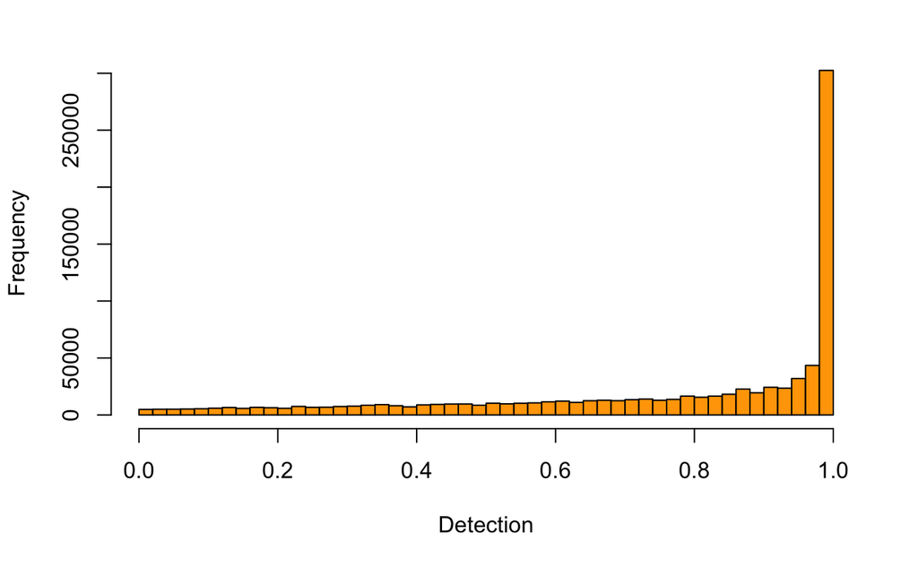

```r
hist(dataNorm$other$Detection, breaks=50, col="orange", xlab="Detection", main="")
```

We only keep probes that have Detection>0.95 (i.e. p-values less than 0.05) in at least three samples, because the min number of samples in our groups is 3.

```r
keep <- rowSums(dataNorm$other$Detection>0.95) >= 3 & !is.na(dataNorm$genes$Symbol)
dataNormFilt <- dataNorm[keep,]
dataNormFilt <- dataNormFilt[!is.na(dataNormFilt$genes$GeneID),]
```

## Quality control

#### Quality control by looking at the boxplots and RLE plots of the samples.

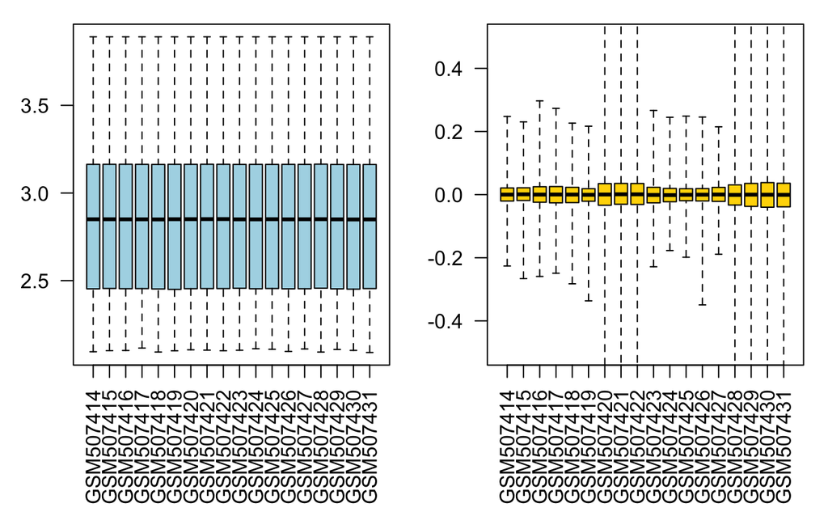

```r
par(mar=c(6,3,1,1))
par(mfrow=c(1,2))
boxplot(log2(dataNormFilt$E),range=0,ylab="log2 intensity",
        las=2, col="light blue")
boxplot(log2(dataNormFilt$E)- rowMedians(log2(dataNormFilt$E)),
        las=2, ylim=c(-0.5, 0.5), col="gold", range=0)
```

#### Quality control by looking at the MDS plots

```r
cols <- c(brewer.pal(8, "Set1"), brewer.pal(8, "Set2"), brewer.pal(8, "Set3"))
sampleInfo
```

|  | title | geo_accession | group |
| --- | --- | --- | --- |
| GSM507414 | Control_48hrs_rep1 | GSM507414 | Control_48hrs |
| GSM507415 | Control_48hrs_rep2 | GSM507415 | Control_48hrs |
| GSM507416 | Control_48hrs_rep3 | GSM507416 | Control_48hrs |
| GSM507417 | Control_18hrs_rep1 | GSM507417 | Control_18hrs |
| GSM507418 | Control_18hrs_rep2 | GSM507418 | Control_18hrs |
| GSM507419 | Control_18hrs_rep3 | GSM507419 | Control_18hrs |
| GSM507420 | TGF-beta_48hrs_rep1 | GSM507420 | TGF-beta_48hrs |
| GSM507421 | TGF-beta_48hrs_rep2 | GSM507421 | TGF-beta_48hrs |
| GSM507422 | TGF-beta_48hrs_rep3 | GSM507422 | TGF-beta_48hrs |
| GSM507423 | C-peptide_48hrs_rep1 | GSM507423 | C-peptide_48hrs |

[output cut: 8 more lines]

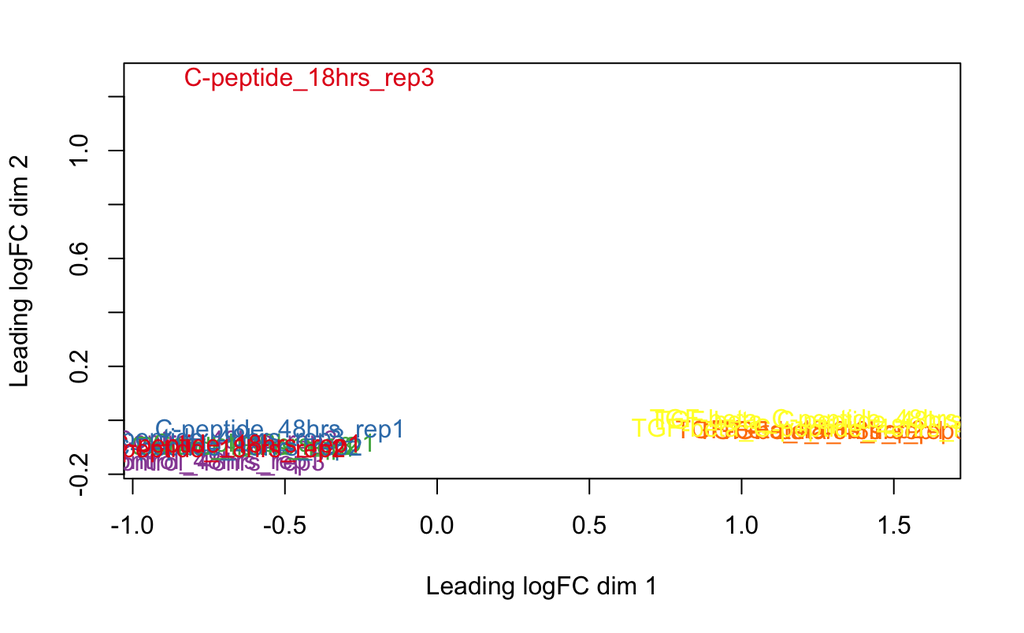

```r
plotMDS(dataNormFilt,labels=sampleInfo$title, col=cols[as.factor(sampleInfo$group)])
```

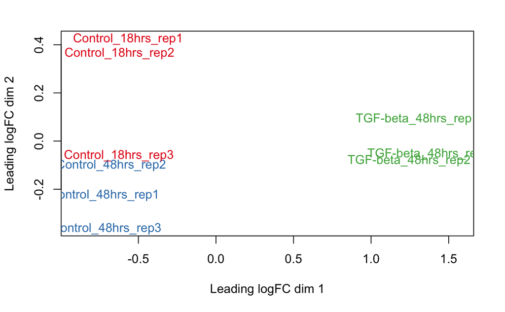

```r
toPlot<- c(1:9)
plotMDS(dataNormFilt[,toPlot],labels=sampleInfo$title[toPlot], col=cols[as.factor(sampleInfo$group[toPlot])])
```

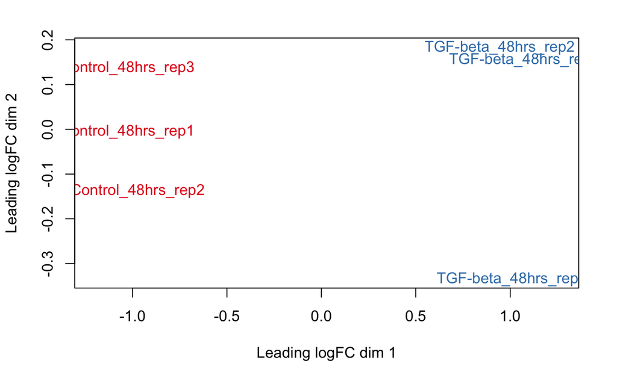

```r
toPlot<- c(1:3, 7:9)
plotMDS(dataNormFilt[,toPlot],labels=sampleInfo$title[toPlot], col=cols[as.factor(sampleInfo$group[toPlot])])
```

#### Quality control using hierarchical clustering

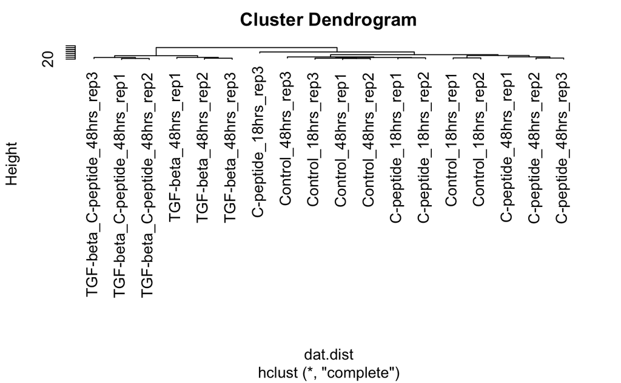

```r
tempDataNorm <- dataNormFilt$E
  # change column names to be short meaningful names:
colnames(tempDataNorm)<- sampleInfo$title
  # calculating distance:
dat.dist<- dist(t(tempDataNorm))
  # hierarchical clustering:
hc<- hclust(dat.dist)
##----- simple clustering:
plot(hc)
```

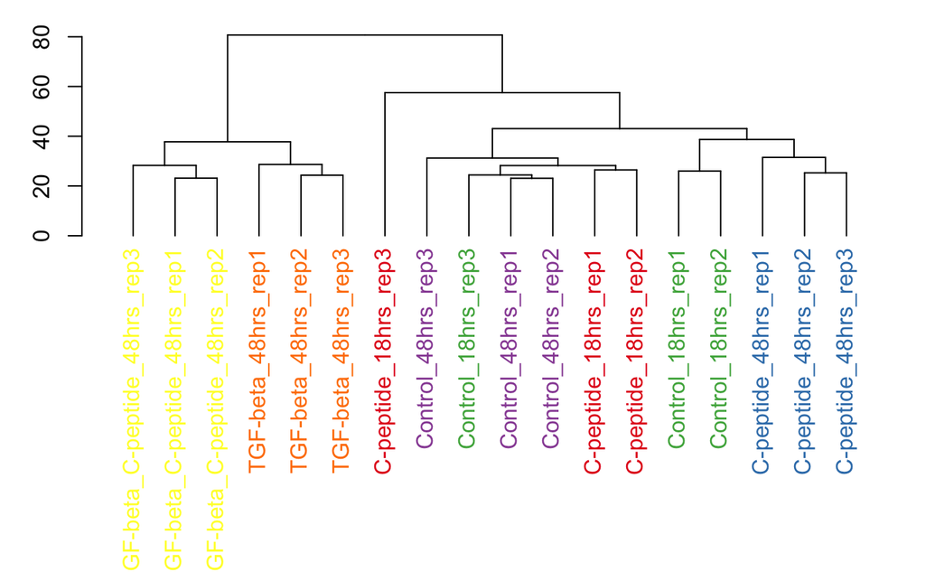

```r
##----- or to have a bit prettier plot using packaage dendextend:
  # make dendrogram of hc:
par(mar=c(12,3,1,1))
dend<- as.dendrogram(hc)
  # choose two colors for two groups "control" and "TGFb":
colorCodes<- cols
  # Assigning the labels of dendrogram object with new colors:
labels_colors(dend) <- colorCodes[as.factor(sampleInfo$group)][order.dendrogram(dend)]
#   # Plotting the new dendrogram
plot(dend)
```

Look at the correlation between the replicates.

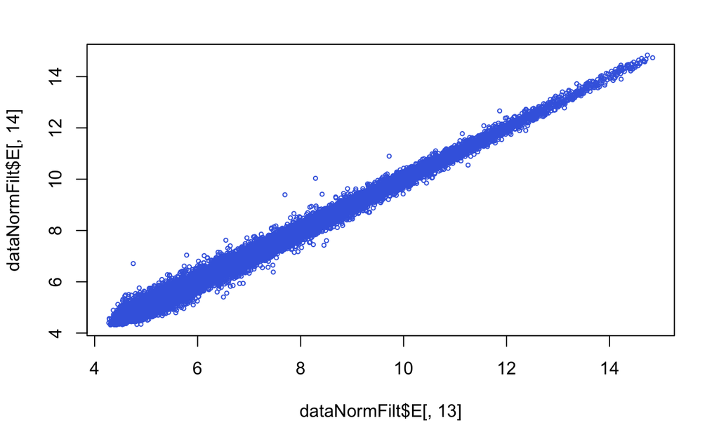

```r
plot(dataNormFilt$E[, 13], dataNormFilt$E[,14], col="royal blue", cex=0.5)
```

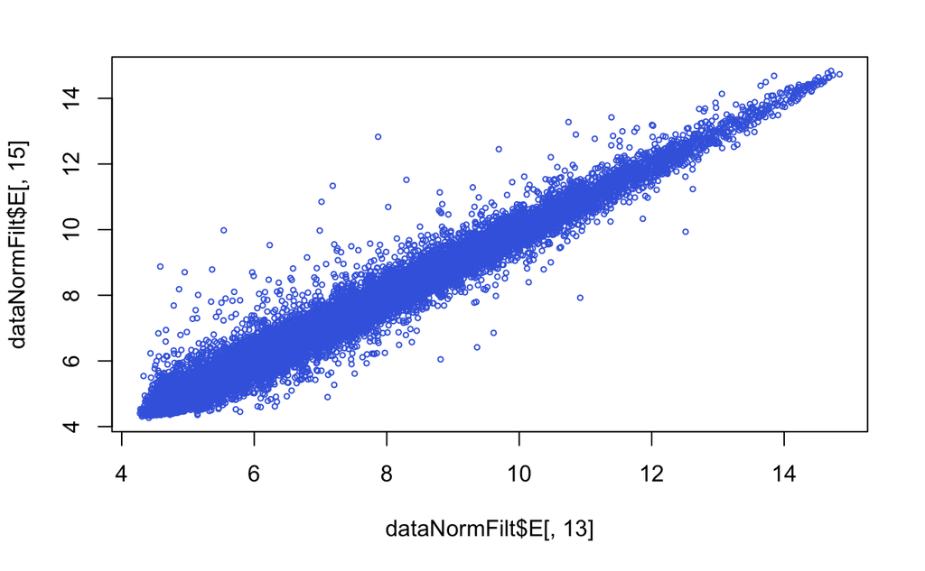

```r
plot(dataNormFilt$E[, 13], dataNormFilt$E[,15], col="royal blue", cex=0.5)
```

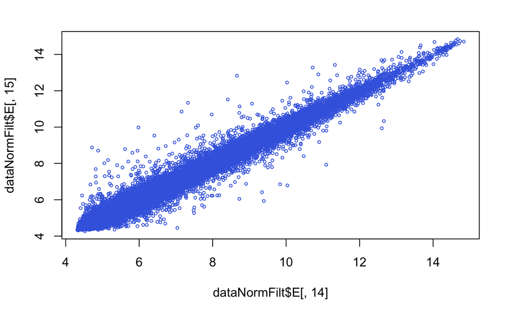

```r
plot(dataNormFilt$E[, 14], dataNormFilt$E[,15], col="royal blue", cex=0.5)
```

Look at the MA plots of the replicates

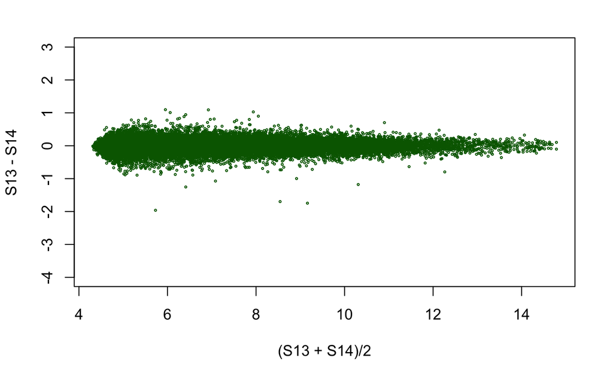

```r
S13<- dataNormFilt$E[, 13]
S14<- dataNormFilt$E[, 14]
S15<- dataNormFilt$E[,15]
plot( (S13+S14)/2, S13-S14, cex=0.3, ylim=c(-4, 3), col="dark green")
```

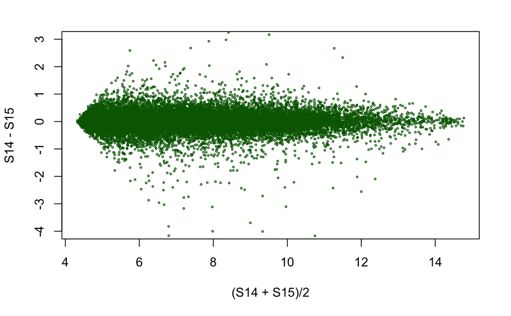

```r
plot( (S14+S15)/2, S14-S15, cex=0.3, ylim=c(-4, 3), col="dark green")
```

## DE analysis

Now, we performe DE analysis using limma. Here, we only want to compare two groups: TGFb-48 with control-48.

```r
groups<- sampleInfo$group
design<- model.matrix ( ~ 0 + groups)
colnames(design)<- c("Cpep_18", "Cpep_48", "Ctrl_18", "Ctrl_48", "TGFb_48", "TGFb_Cpep_48")
design
```

```
   Cpep_18 Cpep_48 Ctrl_18 Ctrl_48 TGFb_48 TGFb_Cpep_48
1        0       0       0       1       0            0
2        0       0       0       1       0            0
3        0       0       0       1       0            0
4        0       0       1       0       0            0
5        0       0       1       0       0            0
6        0       0       1       0       0            0
7        0       0       0       0       1            0
8        0       0       0       0       1            0
9        0       0       0       0       1            0
10       0       1       0       0       0            0
11       0       1       0       0       0            0
12       0       1       0       0       0            0
13       1       0       0       0       0            0
14       1       0       0       0       0            0
15       1       0       0       0       0            0
16       0       0       0       0       0            1
17       0       0       0       0       0            1
18       0       0       0       0       0            1
attr(,"assign")
[1] 1 1 1 1 1 1
attr(,"contrasts")
attr(,"contrasts")$groups
[1] "contr.treatment"
```

```r
fit<-lmFit(dataNormFilt, design)
contrastMat<- makeContrasts(TGFb_ctrl_48= TGFb_48 - Ctrl_48,
                            levels=design)
contrastMat
```

```
              Contrasts
Levels         TGFb_ctrl_48
  Cpep_18                 0
  Cpep_48                 0
  Ctrl_18                 0
  Ctrl_48                -1
  TGFb_48                 1
  TGFb_Cpep_48            0
```

```r
fit2<- contrasts.fit(fit,contrastMat)
fit2<- eBayes(fit2, robust = T, trend=T)
summary(decideTests(fit2, method="global"))
```

```
   TGFb_ctrl_48
-1         3300
0         11085
1          3448
```

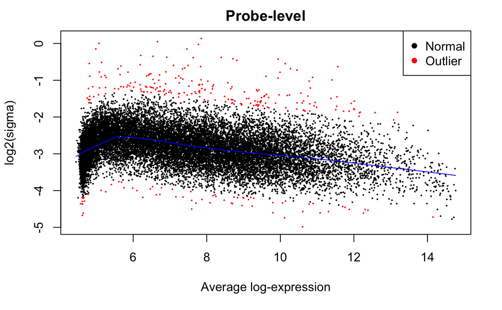

```r
## To check the mean-variance relationship of the expression data:
plotSA(fit2, main="Probe-level")
```

Let’s look at the top differentially expressed probes

```r
toptable(fit2, coef=1)
```

|  | logFC | t | P.Value | adj.P.Val | B |
| --- | --- | --- | --- | --- | --- |
| 2260241 | 3.320552 | 36.07209 | 7.432898e-19 | 1.325509e-14 | 32.71061 |
| 3400307 | -3.251312 | -33.95961 | 2.280358e-18 | 2.033281e-14 | 31.73836 |
| 3710161 | 2.857344 | 31.05854 | 1.193223e-17 | 7.092914e-14 | 30.26795 |
| 4760095 | 4.085000 | 29.24480 | 3.628442e-17 | 1.298804e-13 | 29.25845 |
| 6840609 | 3.950524 | 29.14841 | 3.856443e-17 | 1.298804e-13 | 29.20267 |
| 3890523 | 2.980345 | 28.95167 | 4.369888e-17 | 1.298804e-13 | 29.08813 |
| 2650564 | -3.319927 | -28.29090 | 6.689745e-17 | 1.704260e-13 | 28.69644 |
| 2070630 | 3.391548 | 27.88296 | 8.742906e-17 | 1.948903e-13 | 28.44913 |
| 1510300 | -2.667746 | -27.24215 | 1.341482e-16 | 2.658072e-13 | 28.05185 |
| 5270022 | 4.208280 | 26.75882 | 1.864661e-16 | 3.325250e-13 | 27.74485 |

```r
## we can also get the test statistics for all the genes by setting n="inf"
allStats<- toptable(fit2, coef=1, n="inf", sort.by="none")
```

Look at the distribution of p-values

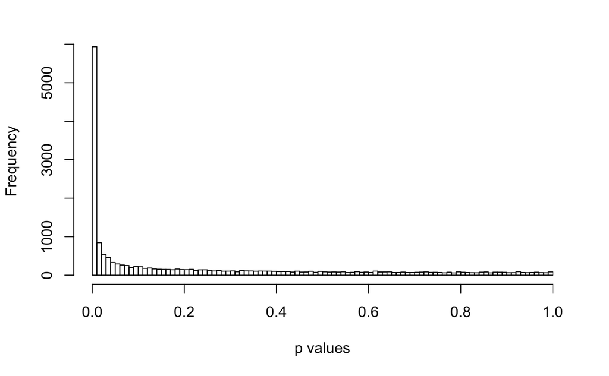

```r
hist(allStats$P.Value, breaks=100, xlab="p values", main="")
```

Generate volcano plot

```r
par(mfrow=c(1,2))
## use the function available through limma:
volcanoplot(fit2, coef=1, highlight=6, names=dataNormFilt$genes$Symbol,
            xlab="Log Fold Change", ylab="Log Odds", pch=16, cex=0.35)
## make your own volcano plot
plot(allStats$logFC, -log10(allStats$P.Value),
     cex=0.4, xlab="Log fold change", ylab="-log10(p value)")
```

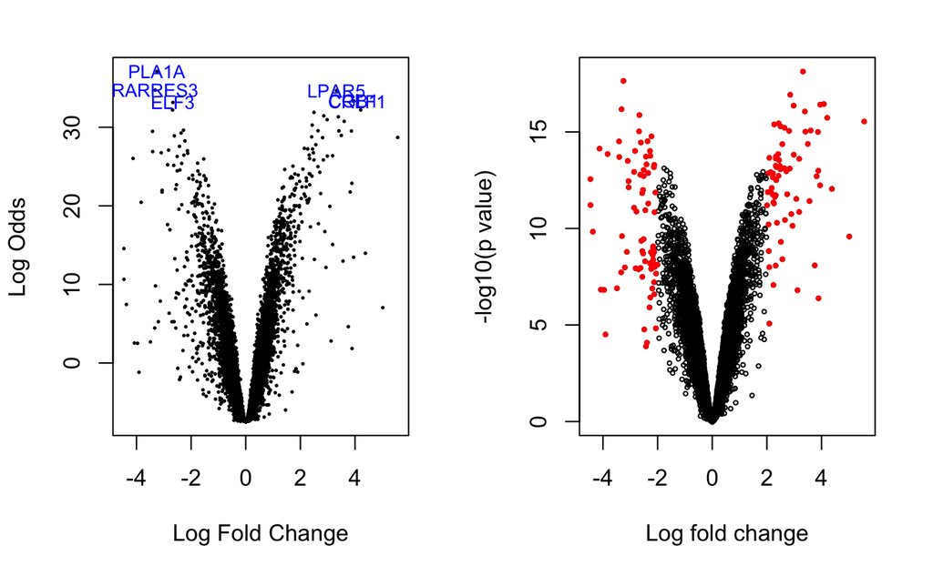

```r
points(allStats$logFC[allStats$adj.P.Val<0.05 & abs(allStats$logFC)>2],
       -log10(allStats$P.Value)[allStats$adj.P.Val<0.05 & abs(allStats$logFC)>2] ,
       col="red", cex=0.4, pch=19)
```

Now, we extract differentially expressed probes based on our criteria.

```r
DEProbes_indx<- which(allStats$adj.P.Val<0.05 & abs(allStats$logFC)>2) ## 148 probes
DEProbes<-dataNormFilt[DEProbes_indx,]       # it has expression values for DEProbes
DEpvals<- allStats[DEProbes_indx,]       # it gives p vals, logFC etc related to DEProbes
DEProbes$genes<- data.frame(DEProbes$genes, DEpvals)
save(DEProbes, file= "DEProbes_stats_Illumina.RData")
```